# Appendix D. EVMP Willow Statistical Analyses

**Willow Macroplot Statistical Analyses**

*Repository:*  
https://github.com/egage/EVMP

```r
# custom gradients and palettes
dbhclass.gradient5 <- c("#26185F", "#0095AF", "#9ADCBB", "#FCFFDD", "grey50")

colfunc1<-colorRampPalette(c("#26185F","#0095AF","#9ADCBB", "#FCFFDD"))
colfunc2<-colorRampPalette(c("#0095AF","#9ADCBB", "#FCFFDD"))
colfunc3<-colorRampPalette(c("#0095AF","#9ADCBB"))
colfunc3_RdBu <- colorRampPalette(c("#EF8A62", "#FDDBC7", "#D1E5F0", "#67A9CF"))

# plot(rep(1,50),col=(colfunc1(50)), pch=19,cex=2)
# plot(rep(1,5),col=(colfunc1(5)), pch=19,cex=2)
pal.5a <- colfunc1(5)
pal.7a <- colfunc1(7)

# palette3 <- RColorBrewer::brewer.pal(6,"RdBu")
# RColorBrewer::display.brewer.pal(6,"RdBu")
```

# Introduction

This document contains code for running statistical analyses of of Elk Vegetation Management Plan (EVMP) data collected through the 2018 sampling season. Analyses are limited to macroplot data from plots established in riparian areas in areas of the elk winter range and Kawuneeche Valley (i.e., “willow” plots, see Zeigenfuss et al. 2011). Analyses are provided as a supplement to the NPS NRR Report “Monitoring of Vegetation Response to Elk Population and Habitat Management in Rocky Mountain National Park - Analysis of Elk Vegetation Management Plan monitoring Data: 2008–2018.” For information on sampling and the broader analysis and interpretation of the results, refer to the project report, past analyses (Linda C. Zeigenfuss and Johnson 2015), and the original EVMP monitoring plan (Linda C. Zeigenfuss, Johnson, and Wiebe 2011).

# Methods

The code and results presented here build on derived data produced in a separate code document focused on ingesting, compiling, and cleaning raw data provided by RMNP staff (Appendix B). Extensive “munging” of raw files was required, so the decision was made to separate code used to pre-process raw data from code used for the analyses presented here. Likewise, separate code documents were developed for other distinct elements of the larger EVMP (e.g., aspen and upland plots). In general, packages included in the “Tidyverse” ecosystem of R packages were used for data transformation and visualization (Wickham et al. 2019), although specialized packages particular to specific tasks (e.g., the “bayesplot” plot for visualization of Bayesian posterior distributions) were also used (Gabry et al. 2019).

Bayesian models view a model parameter $\theta$ as a [*random variable*]. In constrast, frequentist models treat model parameters as unknown *constant*. Rather than estimating an unknown constant, Bayesian modeling focuses on an unknown distribution of parameter values.

Using *Bayes’ Law*, model parameters are estimated:

$$\begin{equation} \label{eq:bayeslaw}
P(\theta | y, X) = \frac{P(y|\theta,X) \cdot P(\theta)}{P(y)} \propto P(y|\theta,X) \cdot P(\theta).
\end{equation}$$

Where:

- $X$: The observed data
- $y$: The outcomes
- $P(\theta|y,X)$: Our view of the possible value of our model parameters after seeing the data
- $P(y|\theta,X)$: The likelihood of seeing the current outcome conditioned on the data we have and a specific parameter value
- $P(\theta)$: Our view of the possible values of our model parameters before observing any actual data, i.e. the *prior*
- $P(y)$: The unconditional probability of the outcome, i.e. the probability after considering all possible parameter. The objective is to estimate the posterior density of parameter $P(\theta|y,X)$, typically described in terms of a point estimate of the expected value of posterior density (e.g., the median of the distribution) and a measure of the variance. To solve for $P(\theta|y,X)$ analytically, the data likelihood $P(y|\theta,X)$, prior $P(\theta)$, and marginal likelihood of outcome $P(y)$ are needed, but because there is usually no closed-form analystical solution, Markov chain Monte Carlo methods are used to numerically solve the posterior density by directly generating random draws of parameters. The general steps in a Bayesian analysis followed included: *Specify a joint distribution for the outcome(s) and all the unknowns, which proportional to a posterior distribution of the unknowns conditional on the observed data*  
  Use Markov Chain Monte Carlo (MCMC) to draw from posterior distribution.  
  *Evaluation of model fit and revise the model as appropriate.

Bayesian repeated measures analyses were fit separately for combined core and non-core winter range, core winter range (WC) and non-core winter range plots (WNC). For willow height, models were fit using weekly informative priors and a gamma distribution with the “stan_glmer” function in the “rstanarm” package (Goodrich et al. 2020)(Brilleman et al. 2018). Gamma regression is commonly used when the response variable is continuous and positive.

For the simplest case a GLM for a continuous outcome is simply a linear model and the likelihood for one observation is a conditionally normal probability density function.
$$\frac{1}{\sigma \sqrt{2 \pi}} e^{-\frac{1}{2}
\left(\frac{y - \mu}{\sigma}\right)^2},$$
where $\mu = \alpha + \mathbf{x}^\top \boldsymbol{\beta}$ is a linear predictor and $\sigma$ is the standard deviation of the error in predicting the outcome, $y$. A linear predictor $\eta = \alpha + \mathbf{x}^\top \boldsymbol{\beta}$ can more generally be related to the conditional mean of the outcome via a link function $g$. This maps the range of values on which the outcome is defined. For the gamma distribution used in the modeling of willow height, the log link function was used. The likelihood is the product of the likelihood contributions of individual observations.

Bayesian analysis requires specifying prior distributions $f(\alpha)$ and $f(\boldsymbol{\beta})$ for the intercept and vector of regression coefficients. Prior distributions were represented by normal distributions with a mean zero and a small standard deviation (scale)). The joint posterior distribution for $\alpha$ and $\boldsymbol{\beta}$ is proportional to the product of the priors and the $N$ likelihood contributions:

$$f\left(\boldsymbol{\beta} | \mathbf{y},\mathbf{X}\right) \propto
f\left(\alpha\right) \times \prod_{k=1}^K f\left(\beta_k\right) \times
\prod_{i=1}^N {f(y_i|\eta_i)},$$

where $\mathbf{X}$ is the matrix of predictors and $\eta$ the linear predictor, i.e., the posterior distribution that `stan_glmer` draws from using MCMC.

Willow cover data were modeled using the beta distribution as the likelihood for the data,
$$f(y_i | a, b) = \frac{y_i^{(a-1)}(1-y_i)^{(b-1)}}{B(a,b)}$$
where $B(\cdot)$ is the beta function. The shape parameters for the distribution are $a$ and $b$ and enter into the model according to the following transformations,
$$a = \mu\cdot\phi \\
b = (1-\mu)\cdot\phi$$

If $g_1(\cdot)$ is some link function, the specification of the shape parameters, $\mu = g_1^{-1}(\mathbf{X}\boldsymbol{\beta})$, where $\boldsymbol{X}$ is a $N\times K$ dimensional matrix of predictors, and $\boldsymbol{\beta}$, is a $K$ dimensional vector of parameters associated with each predictor. $\phi$ is a scalar parameter. With the shape parameter values included, the likelihood takes the form:
$$f(y_i | \mu, \phi) = \frac{y_i^{(\mu\phi-1)}(1-y_i)^{((1-\mu)\phi-1)}}{B(\mu\phi,(1-\mu)\phi)}$$

Bayesian analysis requires specifying prior distributions $f(\boldsymbol{\beta})$ and $f(\phi)$ for the vector of regression coefficients and $\phi$. When modeling $\phi$ with a linear predictor a full Bayesian analysis requires specifying the prior distributions $f(\boldsymbol{\beta})$ and $f(\boldsymbol{\gamma})$.

With a single set of explanatory variables, the posterior distribution of $\boldsymbol{\beta}$ and $\phi$ is proportional to the product of the likelihood contributions, the $K$ priors on the $\beta_k$ parameters, and $\phi$,
$$f(\boldsymbol{\beta},\phi|\mathbf{y},\mathbf{X}) \propto
\prod_{i=1}^N f(y_i | a, b) \times
\prod_{k=1}^K f(\beta_k) \times
f(\phi)$$

With two sets of explanatory variables, the posterior distribution of $\boldsymbol{\beta}$ and $\boldsymbol{\gamma}$ is proportional to the product of the likelihood contribution, the $K$ priors on the $\beta_k$ parameters, and the $J$ priors on the $\gamma_j$ parameters,

$$f(\boldsymbol{\beta},\boldsymbol{\gamma}|\mathbf{y},\mathbf{X}) \propto
\prod_{i=1}^N f(y_i | a, b) \times
\prod_{k=1}^K f(\beta_k) \times
\prod_{j=1}^J f(\gamma_j)$$

```r
#### Data import and munging
# read in willow. These data are the output of extensive munging accomplished using code in "EVMP_munging_20210131.Rmd"

willow <- read_csv("./output/exported_data/willow_mcro.csv")

## create timeClass var
willow.ht <- willow %>%
  filter(!is.na(PLANT_HT_CM)) %>%
  mutate(timeClass = case_when(yr == 2008 ~ "BL",
                              yr == 2009 ~ "BL",
                              TRUE ~ as.character(yr)))

## chr to factor conversions
willow.ht <- willow.ht %>%
  mutate(timeClass = as.factor(timeClass)) %>%
  mutate(timeClass = fct_relevel(timeClass, "2018", "2013", "BL")) %>%
  mutate(FENCED = as.factor(FENCED))


## clean names
willow.ht <- willow.ht %>%
  janitor::clean_names()

## filter out just the willow species
willow.ht <- willow.ht %>%
  filter(str_detect(species_code, pattern = "SA"))

## filter out 0
willow.ht <- willow.ht %>%
  filter(plant_ht_cm > 0)

## reorder the time class
willow.ht <- willow.ht %>%
  mutate(time_class = fct_rev(time_class))

## factor reverse: fenced
willow.ht <- willow.ht %>%
  mutate(fenced = fct_rev(fenced))
```

```r
## create separate df for WC, WNC, combined WC & WNC, and KV


willow.ht.wc <- willow.ht %>%
  filter(site_type == "WC") %>%
  filter(time_class == "BL" | time_class == "2013" | time_class == "2018") %>%
  mutate(time_class = fct_drop(time_class))


# non core
willow.ht.nc <- willow.ht %>%
  # distinct(site_type)
  filter(site_type == "WNC") %>%
  filter(time_class == "BL" | time_class == "2013" | time_class == "2018") %>%
  mutate(time_class = fct_drop(time_class))

# combined WC and WNC
willow.ht.wc.wnc <- willow.ht %>%
  # distinct(site_type)
  filter(site_type == "WNC" | site_type == "WC") %>%
  filter(time_class == "BL" | time_class == "2013" | time_class == "2018") %>%
  mutate(time_class = fct_drop(time_class))

# kw (note: different munging workflow needed b/c of different sampling yrs)
willow.ht.wk <- willow %>%
  clean_names() %>%
  filter(str_detect(species_code, pattern = "SA")) %>%
  filter(site_type == "WK") %>%
  mutate(fenced = as.factor(fenced)) %>%
  filter(plant_ht_cm > 0) %>%
  mutate(time_class = as.factor(time_class)) %>%
  mutate(fenced = fct_rev(fenced)) %>%
  mutate(time_class = fct_drop(time_class))
```

# Results

## Willow Height - Combined Winter Range Macroplot Data

**Histograms of Willow Height**

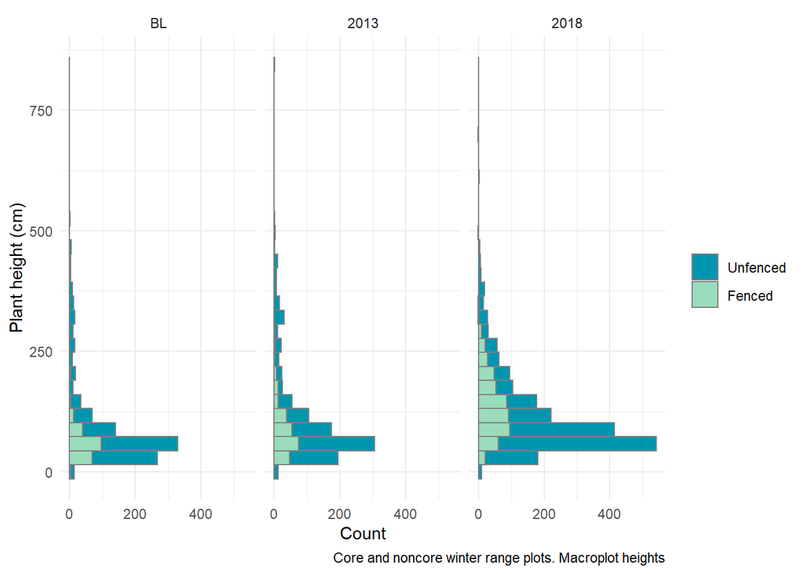

```r
## histogram
willow.ht.wc.wnc %>%
  ggplot() +
  geom_histogram(aes(plant_ht_cm, fill = fenced), color = "grey50") +
  # viridis::scale_fill_viridis(discrete=TRUE) +
  scale_fill_manual(values = colfunc3(2)) +
  labs(x="Plant height (cm)", y = "Count", fill = "", caption = "Core and noncore winter range plots. Macroplot heights") +
  theme_minimal() +
  facet_wrap(~time_class) +
  coord_flip()
```

```r
ggsave("./output/figures_202107/willow_height/hist_willowht_TC_wcwnc.png", dpi = 300, width = 6.75, height = 3.75)
# ggsave("./output/figures_202107/willow_height/hist_willowht_TC_wcwnc.pdf", width = 6.75, height = 3.75)
```

### Modeling and Posterior Description

```r
## run with gamma
wc.wnc.stmod_TCxF <- stan_glmer(plant_ht_cm ~ time_class*fenced +  (1 | site_id), data = willow.ht.wc.wnc,
                      family=Gamma(link="log"),
                      iter = 8000,
                      )
```

**Prior summary**: plant_ht_cm ~ time_class*fenced + (1 | site_id)

```r
# Get the prior summary
prior_summary(wc.wnc.stmod_TCxF)
```

```
## Priors for model 'wc.wnc.stmod_TCxF'
## ------
## Intercept (after predictors centered)
##  ~ normal(location = 0, scale = 2.5)
##
## Coefficients
##   Specified prior:
##     ~ normal(location = [0,0,0,...], scale = [2.5,2.5,2.5,...])
##   Adjusted prior:
##     ~ normal(location = [0,0,0,...], scale = [5.71,5.00,5.76,...])
##
## Auxiliary (shape)
##  ~ exponential(rate = 1)
##
## Covariance
##  ~ decov(reg. = 1, conc. = 1, shape = 1, scale = 1)
## ------
## See help('prior_summary.stanreg') for more details
```

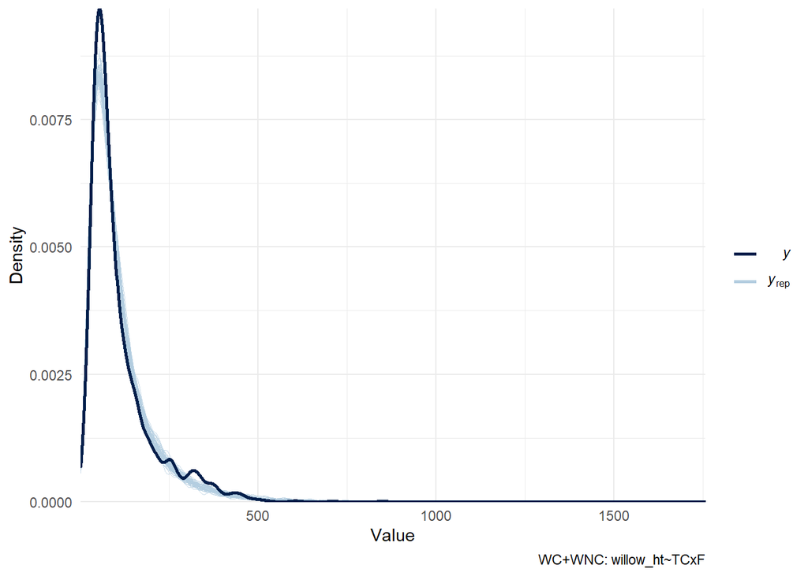

```r
#### PP check plot
ppc.plot(wc.wnc.stmod_TCxF) +
  labs(caption = "WC+WNC: willow_ht~TCxF")
```

```r
ggsave("./output/figures_202107/willow_height/ppc_willowht_wcwnc.png", dpi = 300, width = 4.75, height = 3.75)
# ggsave("./output/figures_202107/willow_height/ppc_willowht_wcwnc.pdf", width = 4.75, height = 3.75)
```

```r
# Extract posteriors
posteriors.wc.wnc.ht <- insight::get_parameters(wc.wnc.stmod_TCxF)

## tidy
posteriors.wc.wnc.ht.tidy <- posteriors.wc.wnc.ht %>%
  pivot_longer(cols = starts_with("time"), names_to = "parameter", values_to = "values")

# posteriors.wc.wnc.ht.tidy %>%
#   ggplot() +
#   geom_density(aes(fill = parameter, x = values),color="grey50", alpha = .25) +
#   # scale_fill_viridis(discrete = TRUE) +
#   scale_fill_manual(values = colfunc2(10)) +
#   # scale_color_manual(values = colfunc2(ncol(posteriors.wc.wnc.ht.tidy))) +
#   theme_minimal()
```

### Effect Description

```r
# use function defined above
fun.sexit.gt(wc.wnc.stmod_TCxF)
```

Effect Existence and Significance Testing

| Parameter | Median | CI | CI_low | CI_high | Direction | Significance | Large |
| --- | --- | --- | --- | --- | --- | --- | --- |
| (Intercept) | 4.59 | 0.9 | 4.47 | 4.71 | 1 | 1 | 1.00 |
| time_class2013 | 0.15 | 0.9 | 0.10 | 0.19 | 1 | 1 | 0.00 |
| time_class2018 | 0.23 | 0.9 | 0.19 | 0.27 | 1 | 1 | 0.00 |
| fencedFenced | -0.55 | 0.9 | -0.78 | -0.33 | 1 | 1 | 0.96 |
| time_class2013:fencedFenced | 0.33 | 0.9 | 0.25 | 0.43 | 1 | 1 | 0.71 |
| time_class2018:fencedFenced | 0.72 | 0.9 | 0.63 | 0.80 | 1 | 1 | 1.00 |

```r
## save as RTF
fun.sexit.gt(wc.wnc.stmod_TCxF) %>%
 tab_header(title = "Combined WC and WNC", subtitle = "Willow Height Posterior Description") %>%
 gt::gtsave(filename = "./output/tables/willow_height/postdesc_willowht_TCxF_wcwnc.rtf")
```

#### Probability of Direction

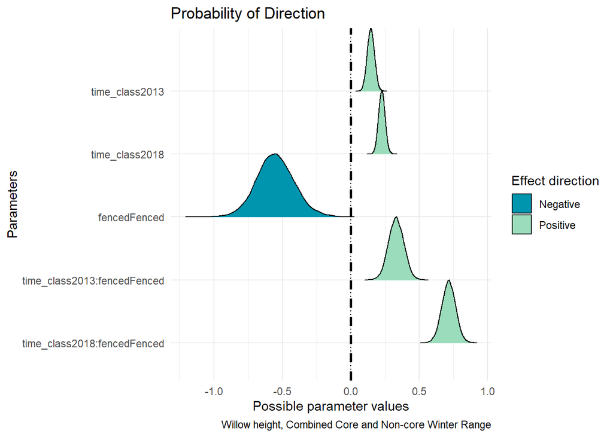

```r
pd.wc.wnc <- p_direction(wc.wnc.stmod_TCxF)
# Visualize the pd
plot(pd.wc.wnc) +
  theme_minimal() +
  geom_vline(aes(xintercept = 0), color= "black", size=1, lty="dashed") +
  labs(caption = "Willow height, Combined Core and Non-core Winter Range") +
  scale_fill_manual(values = colfunc3(2))
```

```r
ggsave("./output/figures_202107/willow_height/pd_willowht_wcwnc.png", width = 6.75, height =3.75, dpi = 300)
ggsave("./output/figures_202107/willow_height/pd_willowht_wcwnc.png", width = 6.75, height =3.75)
```

#### Region of Practical Equivalence (ROPE)

```r
rope.wcwnc <- rope(wc.wnc.stmod_TCxF, ci=0.9)

rope.wcwnc.gt <- rope.wcwnc %>%
  gt() %>%
  tab_header(title = "Percent in ROPE") %>%
  fmt_number(
    columns = 5,
    decimals = 2,
    suffixing = TRUE
  )
rope.wcwnc.gt
```

Percent in ROPE

| Parameter | CI | ROPE_low | ROPE_high | ROPE_Percentage | Effects | Component |
| --- | --- | --- | --- | --- | --- | --- |
| (Intercept) | 0.9 | -0.1 | 0.1 | 0.00 | fixed | conditional |
| time_class2013 | 0.9 | -0.1 | 0.1 | 0.00 | fixed | conditional |
| time_class2018 | 0.9 | -0.1 | 0.1 | 0.00 | fixed | conditional |
| fencedFenced | 0.9 | -0.1 | 0.1 | 0.00 | fixed | conditional |
| time_class2013:fencedFenced | 0.9 | -0.1 | 0.1 | 0.00 | fixed | conditional |
| time_class2018:fencedFenced | 0.9 | -0.1 | 0.1 | 0.00 | fixed | conditional |

```r
# rope.wcwnc.gt %>%
#   gt::gtsave(filename = "./output/tables/willow_height/rope_willowht_wcwnc.rtf")
```

### Contrasts

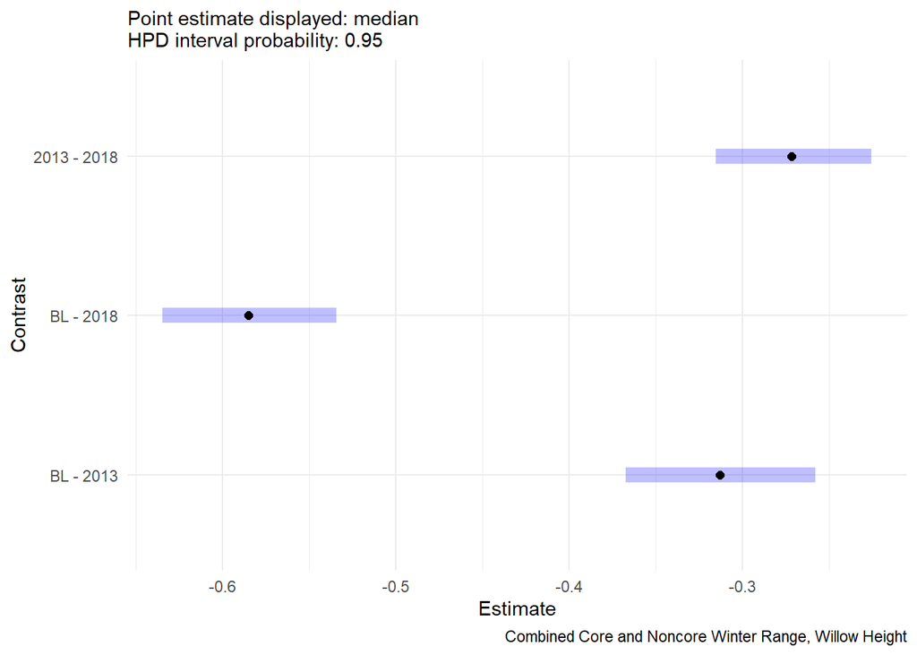

```r
# Results are given on the log (not the response) scale.
# main effects
## main effect: time class
wc.wnc.emm.tc <- emmeans(wc.wnc.stmod_TCxF, ~ time_class)
wc.wnc.pairs.timeClass <- pairs(wc.wnc.emm.tc)

plot(wc.wnc.pairs.timeClass) +
  theme_minimal() +
  labs(subtitle = "Point estimate displayed: median
HPD interval probability: 0.95", x = "Estimate", y = "Contrast", caption = "Combined Core and Noncore Winter Range, Willow Height")
```

```r
## main effect: fencing
wc.wnc.emm.fenced <- emmeans(wc.wnc.stmod_TCxF, ~ fenced)
wc.wnc.pairs.fenced <- pairs(wc.wnc.emm.fenced)

# plot(wc.wnc.pairs.fenced) +
#   theme_minimal() +
#   labs(subtitle = "Point estimate displayed: median
# HPD interval probability: 0.95", x = "Estimate", y = "Contrast", caption = "Combined Core and Noncore Winter Range, Willow Height")

## the above is not used b/c sig of interactions
```

```r
## Effect: TC x fencing
emmeans(wc.wnc.stmod_TCxF, ~ time_class | fenced) %>%
  pairs(reverse=TRUE)
```

```
## fenced = Unfenced:
##  contrast    estimate lower.HPD upper.HPD
##  2013 - BL     0.1471    0.0953     0.197
##  2018 - BL     0.2275    0.1812     0.273
##  2018 - 2013   0.0798    0.0347     0.124
##
## fenced = Fenced:
##  contrast    estimate lower.HPD upper.HPD
##  2013 - BL     0.4791    0.3823     0.575
##  2018 - BL     0.9430    0.8538     1.029
##  2018 - 2013   0.4637    0.3882     0.542
##
## Point estimate displayed: median
## Results are given on the log (not the response) scale.
## HPD interval probability: 0.95
```

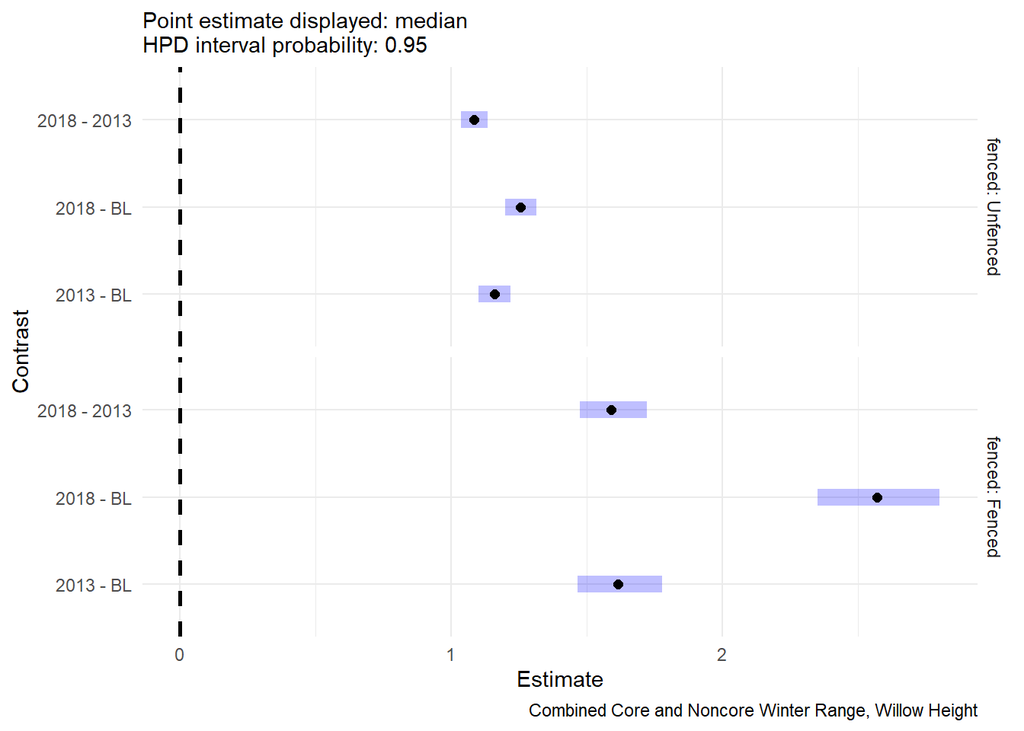

```r
emmeans(wc.wnc.stmod_TCxF, ~ time_class | fenced) %>%
  pairs(reverse=TRUE) %>%
  plot(type = "response") +
  theme_minimal() +
  geom_vline(aes(xintercept = 0), color= "black", size=1, lty="dashed") +
  labs(subtitle = "Point estimate displayed: median
HPD interval probability: 0.95", x = "Estimate", y = "Contrast", caption = "Combined Core and Noncore Winter Range, Willow Height")
```

```r
# ggsave("./output/figures_202107/willow_height/emm_willowht_TCxF_wcwnc.pdf", width = 4.5, height = 3.55) # save plot
ggsave("./output/figures_202107/willow_height/emm_willowht_TCxF_wcwnc.png", width = 4.5, height = 3.55) # save plot

# table of contrasts
emmeans(wc.wnc.stmod_TCxF, ~ time_class | fenced) %>%
  pairs(reverse = TRUE) %>%
  as_tibble() %>%
  mutate(across(where(is.numeric),round, 2)) %>%
  gt() %>%
  tab_header(title = "Pairwise contrasts", subtitle = "Results are given on the log scale")
```

Pairwise contrasts

Results are given on the log scale

| contrast | fenced | estimate | lower.HPD | upper.HPD |
| --- | --- | --- | --- | --- |
| 2013 - BL | Unfenced | 0.15 | 0.10 | 0.20 |
| 2018 - BL | Unfenced | 0.23 | 0.18 | 0.27 |
| 2018 - 2013 | Unfenced | 0.08 | 0.03 | 0.12 |
| 2013 - BL | Fenced | 0.48 | 0.38 | 0.57 |
| 2018 - BL | Fenced | 0.94 | 0.85 | 1.03 |
| 2018 - 2013 | Fenced | 0.46 | 0.39 | 0.54 |

```r
# table of contrasts. Results are given on the response scale.
emmeans(wc.wnc.stmod_TCxF, ~ time_class | fenced) %>%
  pairs(reverse = TRUE, type="response") %>%
  as_tibble() %>%
  mutate(across(where(is.numeric),round, 2)) %>%
  gt() %>%
  tab_header(title = "Pairwise contrasts", subtitle = "Results are given on the response scale.")
```

Pairwise contrasts

Results are given on the response scale.

| contrast | fenced | ratio | lower.HPD | upper.HPD |
| --- | --- | --- | --- | --- |
| 2013 / BL | Unfenced | 1.16 | 1.10 | 1.22 |
| 2018 / BL | Unfenced | 1.26 | 1.20 | 1.31 |
| 2018 / 2013 | Unfenced | 1.08 | 1.04 | 1.13 |
| 2013 / BL | Fenced | 1.61 | 1.47 | 1.78 |
| 2018 / BL | Fenced | 2.57 | 2.34 | 2.79 |
| 2018 / 2013 | Fenced | 1.59 | 1.47 | 1.72 |

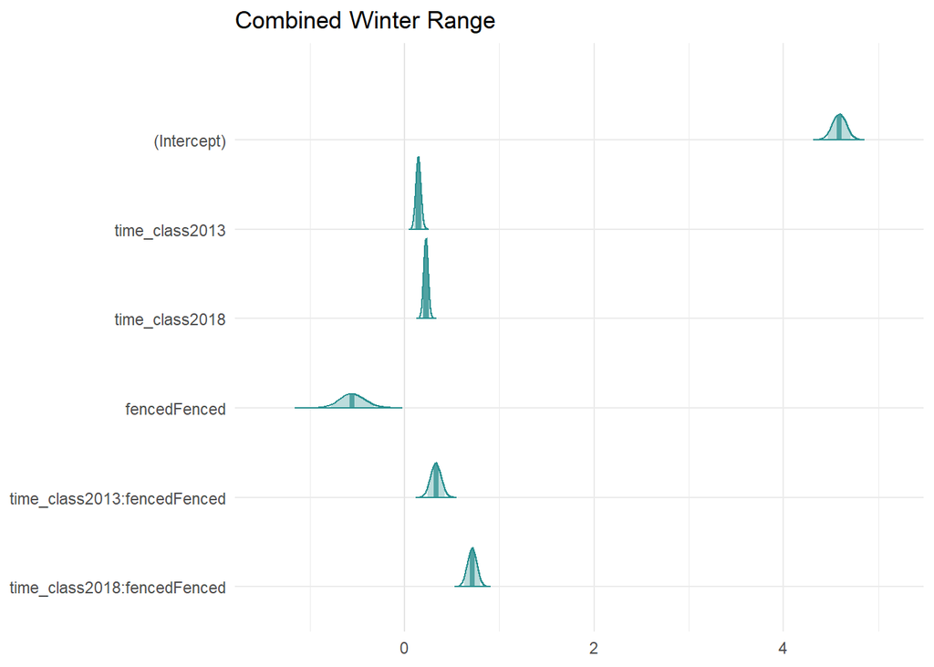

```r
color_scheme_set("teal")

plot.mcmcareas_ht.wcwnc <- mcmc_areas(posteriors.wc.wnc.ht,
           prob = 0.9) +
  ggtitle("Combined Winter Range") +
  theme_minimal() +
  theme(text = element_text(family = 'sans'))

plot.mcmcareas_ht.wcwnc
```

```r
ggsave("./output/figures_202107/willow_height/mcmcarea_willowht_TCxF_wcwnc.png", dpi = 300, width = 6.75, height = 3.75)
# ggsave("./output/figures_202107/willow_height/mcmcarea_willowht_TCxF_wcnc.pdf", width = 6.75, height = 3.75)
```

### Effects of Burning

```r
#### Fenced and burned

stmod_ht.wc.wnc.TCxFxB <- stan_glmer(plant_ht_cm ~ time_class*fenced*burned + (1 | site_id),
                      data = willow.ht.wc.wnc,
                      family=Gamma(link="log"),
                      iter = 8000,
                      seed = 1234
                      )
```

**Prior summary** height ~ time_class * burned * fenced + (1 | site_id)

```r
prior_summary(stmod_ht.wc.wnc.TCxFxB)
```

```
## Priors for model 'stmod_ht.wc.wnc.TCxFxB'
## ------
## Intercept (after predictors centered)
##  ~ normal(location = 0, scale = 2.5)
##
## Coefficients
##   Specified prior:
##     ~ normal(location = [0,0,0,...], scale = [2.5,2.5,2.5,...])
##   Adjusted prior:
##     ~ normal(location = [0,0,0,...], scale = [5.71,5.00,5.76,...])
##
## Auxiliary (shape)
##  ~ exponential(rate = 1)
##
## Covariance
##  ~ decov(reg. = 1, conc. = 1, shape = 1, scale = 1)
## ------
## See help('prior_summary.stanreg') for more details
```

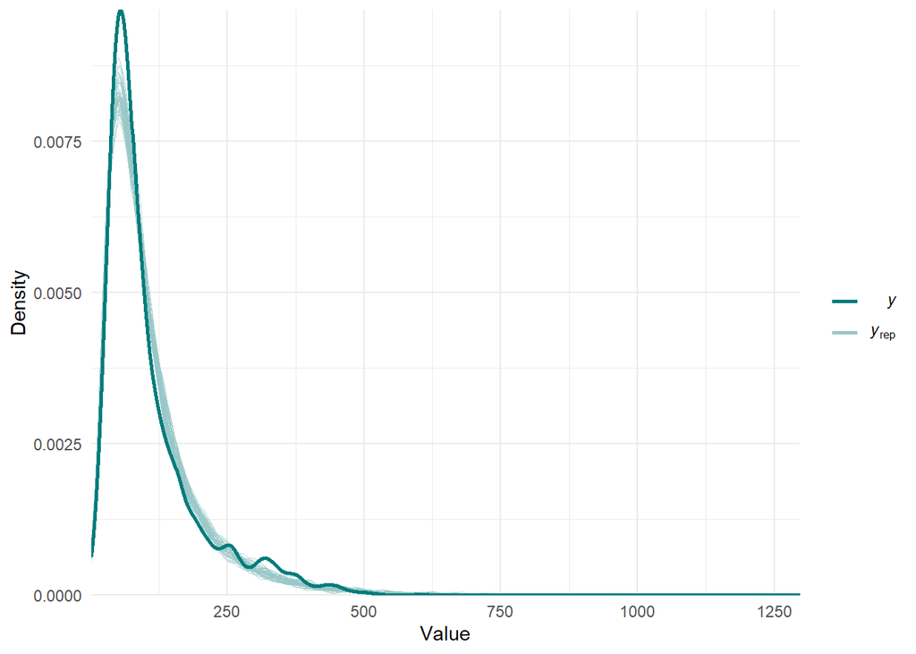

```r
pp_check(stmod_ht.wc.wnc.TCxFxB) +
  labs(x = "Value", y = "Density") +
  theme_minimal()
```

```r
#
ggsave("./output/figures_202107/wc_wnc_willowcover_ppc_TCxFxB.png", dpi = 300, width = 4.75, height = 3.75)
# ggsave("./output/figures_202107/wc_wnc_willowcover_ppc_TCxFxB.pdf", width = 4.75, height = 3.75)
```

```r
# Extract posteriors
posteriors.wc.wnc.ht <- insight::get_parameters(stmod_ht.wc.wnc.TCxFxB)
```

[figure not shown]

```r
##
color_scheme_set("teal")
# color_scheme_set("teal")

plot.mcmcareas_cov.wcwnc <- mcmc_areas(stmod_ht.wc.wnc.TCxFxB,
           prob = 0.9) +
  ggtitle("Combined Winter Range") +
  theme_minimal() +
  theme(text = element_text(family = 'sans')) +
  labs(caption="mcmcarea_willowcov_TC_wcwnc.png")

plot.mcmcareas_cov.wcwnc
```

```r
ggsave("./output/figures_202107/willow_cover/mcmcarea_wilwht_TCxFxB_wcwnc.png", dpi = 300, width = 6.75, height = 11.75)
```

### Effect Description

```r
fun.sexit.gt(stmod_ht.wc.wnc.TCxFxB$stanfit)
```

Effect Existence and Significance Testing

| Parameter | Median | CI | CI_low | CI_high | Direction | Significance | Large |
| --- | --- | --- | --- | --- | --- | --- | --- |
| (Intercept) | 4.25 | 0.9 | 3.95 | 4.57 | 1.00 | 1.00 | 1.00 |
| time_class2013 | -0.39 | 0.9 | -0.62 | -0.17 | 1.00 | 0.99 | 0.74 |
| time_class2018 | -0.17 | 0.9 | -0.40 | 0.05 | 0.90 | 0.82 | 0.18 |
| fencedFenced | -0.48 | 0.9 | -0.87 | -0.05 | 0.97 | 0.95 | 0.76 |
| burnedUnburned | 0.44 | 0.9 | 0.11 | 0.77 | 0.99 | 0.97 | 0.76 |
| time_class2013:fencedFenced | 0.71 | 0.9 | 0.43 | 0.98 | 1.00 | 1.00 | 0.99 |
| time_class2018:fencedFenced | 1.21 | 0.9 | 0.94 | 1.47 | 1.00 | 1.00 | 1.00 |
| time_class2013:burnedUnburned | 0.56 | 0.9 | 0.32 | 0.79 | 1.00 | 1.00 | 0.97 |
| time_class2018:burnedUnburned | 0.41 | 0.9 | 0.18 | 0.64 | 1.00 | 1.00 | 0.79 |
| fencedFenced:burnedUnburned | 0.03 | 0.9 | -0.46 | 0.53 | 0.54 | 0.48 | 0.19 |
| time_class2013:fencedFenced:burnedUnburned | -0.27 | 0.9 | -0.57 | 0.02 | 0.93 | 0.89 | 0.44 |
| time_class2018:fencedFenced:burnedUnburned | -0.58 | 0.9 | -0.87 | -0.30 | 1.00 | 1.00 | 0.95 |
| shape | 4.10 | 0.9 | 3.95 | 4.24 | 1.00 | 1.00 | 1.00 |
| mean_PPD | 108.44 | 0.9 | 106.12 | 110.79 | 1.00 | 1.00 | 1.00 |
| log-posterior | -20619.95 | 0.9 | -20636.84 | -20603.20 | 1.00 | 1.00 | 1.00 |

```r
## Effect: TC x fencing
wcwnc.emm.TCxFxB <- emmeans(stmod_ht.wc.wnc.TCxFxB, ~ time_class | fenced | burned)
# wcwnc.emm.TCxFxB <- pairs(wcwnc.emm.TCxFxB, reverse = TRUE)

wcwnc.emm.TCxFxB
```

```
## fenced = Unfenced, burned = Burned:
##  time_class emmean lower.HPD upper.HPD
##  BL           4.25      3.87      4.61
##  2013         3.86      3.50      4.22
##  2018         4.07      3.72      4.44
##
## fenced = Fenced, burned = Burned:
##  time_class emmean lower.HPD upper.HPD
##  BL           3.77      3.45      4.09
##  2013         4.08      3.78      4.38
##  2018         4.81      4.51      5.10
##
## fenced = Unfenced, burned = Unburned:
##  time_class emmean lower.HPD upper.HPD
##  BL           4.69      4.55      4.83
##  2013         4.86      4.72      4.99
##  2018         4.93      4.79      5.06
##
## fenced = Fenced, burned = Unburned:
##  time_class emmean lower.HPD upper.HPD
##  BL           4.25      3.96      4.54
##  2013         4.84      4.56      5.13
##  2018         5.11      4.82      5.38
##
## Point estimate displayed: median
## Results are given on the log (not the response) scale.
## HPD interval probability: 0.95
```

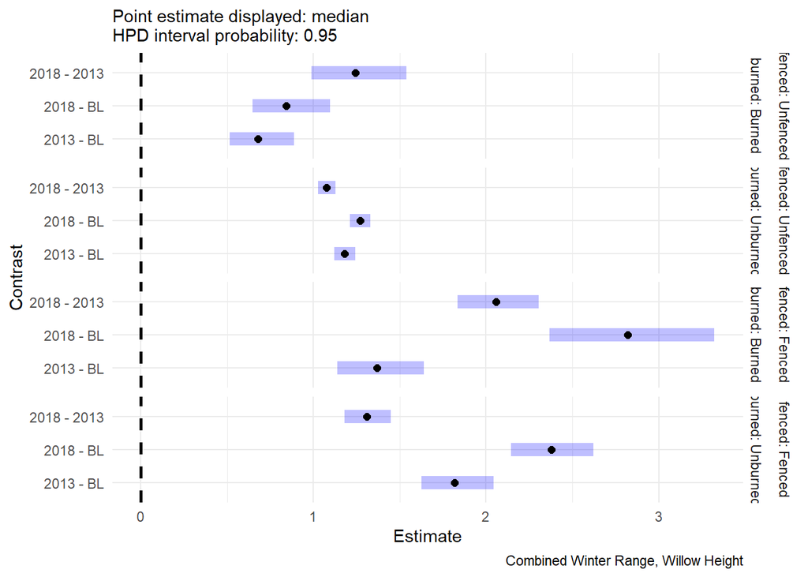

```r
emmeans(stmod_ht.wc.wnc.TCxFxB, ~ time_class | fenced | burned) %>%
  pairs(reverse = TRUE) %>%
  plot(type="response") +
  theme_minimal() +
  geom_vline(aes(xintercept = 0), color= "black", size=1, lty="dashed") +
  labs(subtitle = "Point estimate displayed: median
HPD interval probability: 0.95", x = "Estimate", y = "Contrast", caption = "Combined Winter Range, Willow Height")
```

```r
ggsave("./output/figures_202107/willow_height/emm_willowht_TCxFxB_wcwnc.png", width = 4.5, height = 3.55) # save plot

# table of contrasts
emmeans(wcwnc.emm.TCxFxB, ~ time_class | fenced) %>%
  pairs(reverse = TRUE) %>%
  as_tibble() %>%
  mutate(across(where(is.numeric),round, 2)) %>%
  gt() %>%
  tab_header(title = "Pairwise contrasts", subtitle = "Results are given on the log scale")
```

Pairwise contrasts

Results are given on the log scale

| contrast | fenced | estimate | lower.HPD | upper.HPD |
| --- | --- | --- | --- | --- |
| 2013 - BL | Unfenced | -0.11 | -0.25 | 0.03 |
| 2018 - BL | Unfenced | 0.03 | -0.11 | 0.16 |
| 2018 - 2013 | Unfenced | 0.14 | 0.03 | 0.26 |
| 2013 - BL | Fenced | 0.46 | 0.35 | 0.56 |
| 2018 - BL | Fenced | 0.95 | 0.85 | 1.05 |
| 2018 - 2013 | Fenced | 0.49 | 0.42 | 0.57 |

```r
# table of contrasts. Results are given on the response scale.
emmeans(wcwnc.emm.TCxFxB, ~ time_class | fenced) %>%
  pairs(reverse = TRUE, type="response") %>%
  as_tibble() %>%
  mutate(across(where(is.numeric),round, 2)) %>%
  gt() %>%
  tab_header(title = "Pairwise contrasts", subtitle = "Results are given on the response scale.")
```

Pairwise contrasts

Results are given on the response scale.

| contrast | fenced | ratio | lower.HPD | upper.HPD |
| --- | --- | --- | --- | --- |
| 2013 / BL | Unfenced | 0.89 | 0.77 | 1.02 |
| 2018 / BL | Unfenced | 1.03 | 0.90 | 1.17 |
| 2018 / 2013 | Unfenced | 1.16 | 1.03 | 1.29 |
| 2013 / BL | Fenced | 1.58 | 1.41 | 1.75 |
| 2018 / BL | Fenced | 2.59 | 2.34 | 2.85 |
| 2018 / 2013 | Fenced | 1.64 | 1.52 | 1.77 |

## Willow Height - Core Winter Range Macroplot Data

**Histograms of Willow Height**

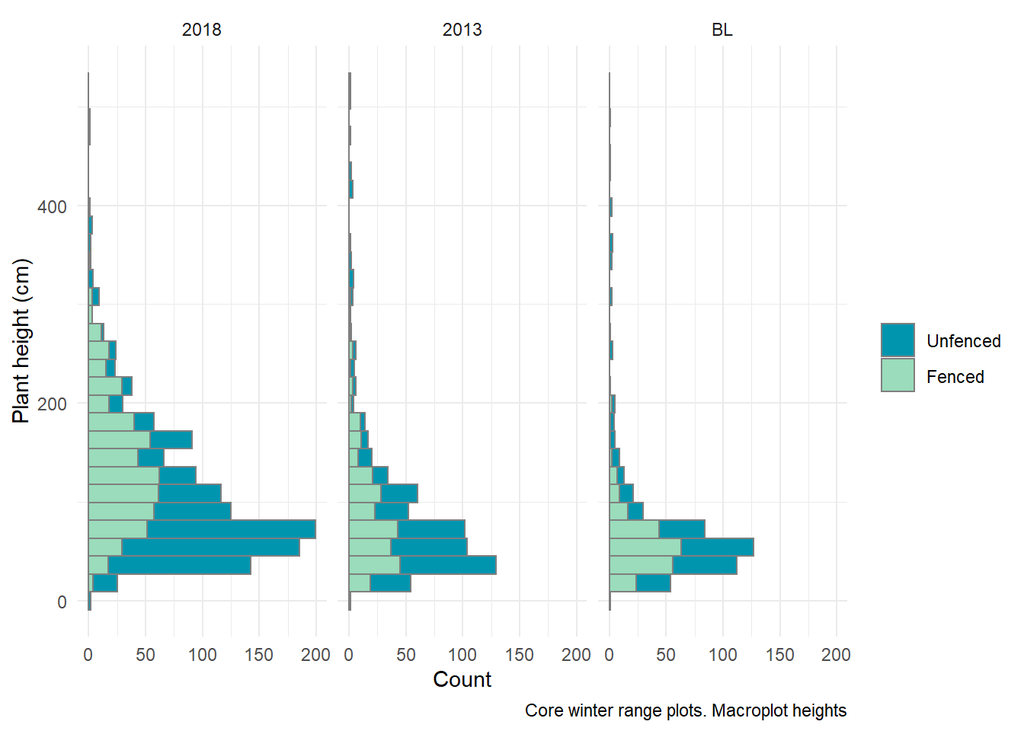

```r
willow.ht.wc %>%
  mutate(time_class = fct_rev(time_class)) %>%
  ggplot() +
  # geom_density(aes(plant_ht_cm, fill = fenced), color = "black") +
  geom_histogram(aes(plant_ht_cm, fill = fenced), color = "grey50") +
  # viridis::scale_fill_viridis(discrete=TRUE) +
  scale_fill_manual(values = colfunc3(2)) +
  labs(x="Plant height (cm)", y = "Count", fill = "", caption = "Core winter range plots. Macroplot heights") +
  theme_minimal() +
  facet_wrap(~time_class) +
  coord_flip()
```

```r
ggsave("./output/figures_202107/willow_height/hist_willowht_TCxF_wc.png", dpi = 300, width = 6.75, height = 3.75)
# ggsave("./output/figures_202107/willow_height/hist_willowht_TCxF_wc.pdf", width = 6.75, height = 3.75)
```

### Modeling and Posterior Description

```r
#### null model
# Not currently run; run in past as model comparison
# Previously run for comparisons but not otherwise reported
stmod_ht.0 <- stan_glmer(plant_ht_cm ~ 1 + (1 | site_id), data = willow.ht.wc,
                      family=Gamma(link="log"),
                      iter = 8000,
                      seed = 1234
                      )

prior_summary(stmod_ht.0)
pp_check(stmod_ht.0)

#### main factors only
## Run, but not used for reporting after model comparisons
stmod_ht1 <- stan_glmer(plant_ht_cm ~ time_class + fenced + (1 | site_id), data = willow.ht.wc,
                      family=Gamma(link="log"),
                      iter = 8000,
                      seed = 1234
                      )

prior_summary(stmod_ht1)
pp_check(stmod_ht1)
```

```r
#### main factors + interactions
# After model comparisons, this is the selected model reported
stmod_ht2 <- stan_glmer(plant_ht_cm ~ time_class*fenced + (1 | site_id), data = willow.ht.wc,
                      family=Gamma(link="log"),
                      iter = 8000,
                      seed = 1234
                      )

## extract posterior
posteriors.wc.ht <- insight::get_parameters(stmod_ht2)
```

**Prior summary**: plant_ht_cm ~ time_class*fenced + (1 | site_id)

```r
# summary(stmod_ht2)
prior_summary(stmod_ht2)
```

```
## Priors for model 'stmod_ht2'
## ------
## Intercept (after predictors centered)
##  ~ normal(location = 0, scale = 2.5)
##
## Coefficients
##   Specified prior:
##     ~ normal(location = [0,0,0,...], scale = [2.5,2.5,2.5,...])
##   Adjusted prior:
##     ~ normal(location = [0,0,0,...], scale = [5.66,5.01,5.06,...])
##
## Auxiliary (shape)
##  ~ exponential(rate = 1)
##
## Covariance
##  ~ decov(reg. = 1, conc. = 1, shape = 1, scale = 1)
## ------
## See help('prior_summary.stanreg') for more details
```

```r
## model comparison.
## Run originally and code retained. stmod_ht2 selected
loo1 <- loo(stmod_ht1,
            k_threshold = 0.7)
loo2 <- loo(stmod_ht2,
            k_threshold = 0.7)
comp <- loo_compare(loo2, loo1)
print(comp, simplify = FALSE, digits = 2)
```

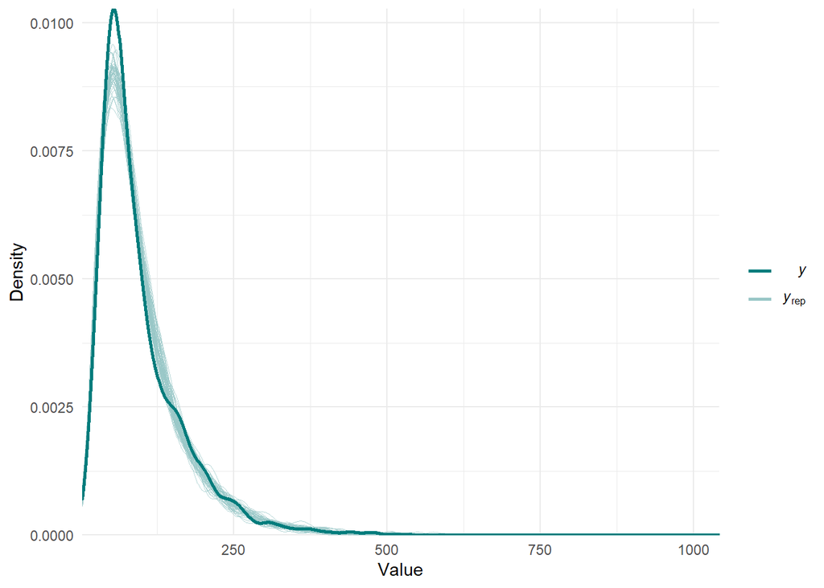

```r
### model checks
ppc.plot(stmod_ht2) +
  labs(x = "Value", y = "Density") +
  theme_minimal()
```

```r
ggsave("./output/figures_202107/willow_height/ppc_willowht_wc.png", width = 4.75, height = 3.75, dpi = 300)
# ggsave("./output/figures_202107/willow_height/ppc_willowht_wc.pdf", width = 4.75, height = 3.75)
```

```r
# full posterior description
fun.desc.post1.gt.rope(stmod_ht2) %>%
  tab_header(title = "Core Winter Range", subtitle = "Willow Height Posterior Description")
```

Core Winter Range

Willow Height Posterior Description

| Parameter | Component | Median | MAD | CI | CI_low | CI_high | pd | ps | ROPE_CI | ROPE_low | ROPE_high | ROPE_Percentage | Rhat | ESS |
| --- | --- | --- | --- | --- | --- | --- | --- | --- | --- | --- | --- | --- | --- | --- |
| (Intercept) | conditional | 4.4 | 0.1 | 0.9 | 4.3 | 4.6 | 1.0 | 1.0 | 0.9 | -0.1 | 0.1 | 0.0 | 1 | 1362.9 |
| time_class2013 | conditional | 0.0 | 0.0 | 0.9 | -0.1 | 0.1 | 0.6 | 0.0 | 0.9 | -0.1 | 0.1 | 1.0 | 1 | 6536.1 |
| time_class2018 | conditional | 0.1 | 0.0 | 0.9 | 0.1 | 0.2 | 1.0 | 0.6 | 0.9 | -0.1 | 0.1 | 0.4 | 1 | 6458.3 |
| fencedFenced | conditional | -0.4 | 0.1 | 0.9 | -0.6 | -0.2 | 1.0 | 1.0 | 0.9 | -0.1 | 0.1 | 0.0 | 1 | 1433.9 |
| time_class2013:fencedFenced | conditional | 0.5 | 0.1 | 0.9 | 0.4 | 0.6 | 1.0 | 1.0 | 0.9 | -0.1 | 0.1 | 0.0 | 1 | 6747.1 |
| time_class2018:fencedFenced | conditional | 0.8 | 0.1 | 0.9 | 0.7 | 0.9 | 1.0 | 1.0 | 0.9 | -0.1 | 0.1 | 0.0 | 1 | 6575.4 |
| shape | distributional | 4.7 | 0.1 | 0.9 | 4.4 | 4.9 | 1.0 | 1.0 | 0.9 | -0.1 | 0.1 | 0.0 | NA | NA |

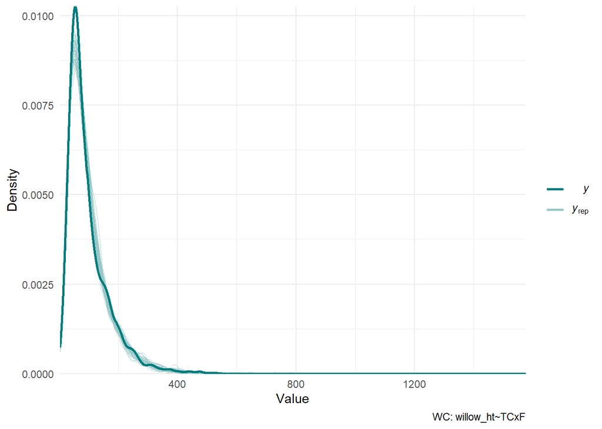

```r
#### PP check plot
ppc.plot(stmod_ht2) +
  labs(caption = "WC: willow_ht~TCxF")
```

```r
# ggsave("./output/figures_202107/willow_height/ppc_willowht_wc.png", dpi = 300, width = 4.75, height = 3.75)
# ggsave("./output/figures_202107/willow_height/ppc_willowht_wc.pdf", width = 4.75, height = 3.75)
```

### Effect Description

```r
fun.sexit.gt(stmod_ht2)
```

Effect Existence and Significance Testing

| Parameter | Median | CI | CI_low | CI_high | Direction | Significance | Large |
| --- | --- | --- | --- | --- | --- | --- | --- |
| (Intercept) | 4.43 | 0.9 | 4.28 | 4.59 | 1.0 | 1.00 | 1.00 |
| time_class2013 | 0.01 | 0.9 | -0.05 | 0.07 | 0.6 | 0.16 | 0.00 |
| time_class2018 | 0.11 | 0.9 | 0.05 | 0.17 | 1.0 | 0.95 | 0.00 |
| fencedFenced | -0.40 | 0.9 | -0.62 | -0.16 | 1.0 | 0.99 | 0.77 |
| time_class2013:fencedFenced | 0.47 | 0.9 | 0.37 | 0.57 | 1.0 | 1.00 | 1.00 |
| time_class2018:fencedFenced | 0.83 | 0.9 | 0.74 | 0.92 | 1.0 | 1.00 | 1.00 |

```r
## save as RTF
fun.sexit.gt(stmod_ht2) %>%
  tab_header(title = "Core Winter Range", subtitle = "Willow Height Posterior Description") %>%
  gt::gtsave(filename = "./output/tables/willow_height/xpostdesc_willowht_TCxF_wc.rtf")
```

#### Probability of Direction

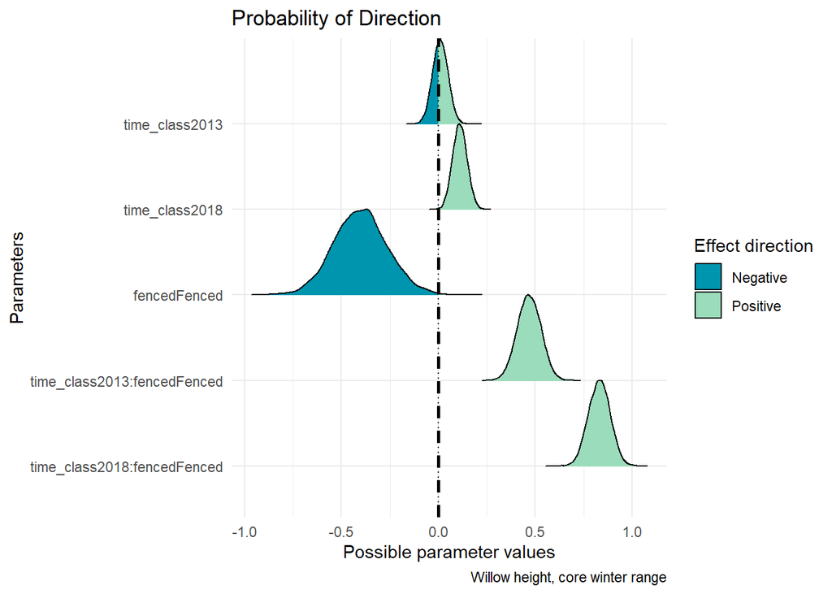

```r
pd.wc <- p_direction(stmod_ht2)

# Visualize the pd
plot(pd.wc) +
  theme_minimal() +
  geom_vline(aes(xintercept = 0), color= "black", size=1, lty="dashed") +
  labs(caption = "Willow height, core winter range") +
  scale_fill_manual(values = colfunc3(2))
```

```r
ggsave("./output/figures_202107/willow_height/pd_willowht_wc.png", width = 6.75, height =3.75, dpi = 300)
# ggsave("./output/figures_202107/willow_height/pd_willowht_wc.pdf", width = 6.75, height =3.75)
```

#### Region of Practical Equivalence (ROPE)

```r
# Region Of Practical Equivalence (ROPE)
rope.wc <- rope(stmod_ht2, ci=0.9)

rope.wc.gt <- rope.wc %>%
  gt() %>%
  tab_header(title = "Percent in ROPE") %>%
  fmt_number(
    columns = 5,
    decimals = 1,
    suffixing = TRUE
  )
rope.wc.gt
```

Percent in ROPE

| Parameter | CI | ROPE_low | ROPE_high | ROPE_Percentage | Effects | Component |
| --- | --- | --- | --- | --- | --- | --- |
| (Intercept) | 0.9 | -0.1 | 0.1 | 0.0 | fixed | conditional |
| time_class2013 | 0.9 | -0.1 | 0.1 | 1.0 | fixed | conditional |
| time_class2018 | 0.9 | -0.1 | 0.1 | 0.4 | fixed | conditional |
| fencedFenced | 0.9 | -0.1 | 0.1 | 0.0 | fixed | conditional |
| time_class2013:fencedFenced | 0.9 | -0.1 | 0.1 | 0.0 | fixed | conditional |
| time_class2018:fencedFenced | 0.9 | -0.1 | 0.1 | 0.0 | fixed | conditional |

```r
# rope.wc.gt %>%
#   gt::gtsave(filename = "./output/tables/willow_height/rope_willowht_wc.rtf")
```

### Contrasts

Results are given on the response scale.

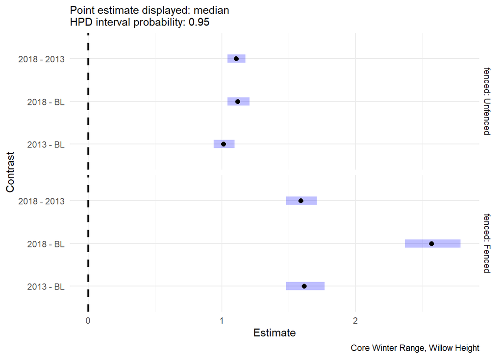

```r
## Effect: TC x fencing
wc.emm.TCxF <- emmeans(stmod_ht2, ~ time_class | fenced)
wc.pairs.TCxF <- pairs(wc.emm.TCxF, reverse = TRUE)

emmeans(stmod_ht2, ~ time_class | fenced) %>%
  pairs(reverse = TRUE) %>%
  plot(type="response") +
  theme_minimal() +
  geom_vline(aes(xintercept = 0), color= "black", size=1, lty="dashed") +
  labs(subtitle = "Point estimate displayed: median
HPD interval probability: 0.95", x = "Estimate", y = "Contrast", caption = "Core Winter Range, Willow Height")
```

```r
ggsave("./output/figures_202107/willow_height/emm_willowht_TCxF_wc.pdf", width = 4.5, height = 3.55) # save plot
ggsave("./output/figures_202107/willow_height/emm_willowht_TCxF_wc.png", width = 4.5, height = 3.55) # save plot

# table of contrasts
emmeans(stmod_ht2, ~ time_class | fenced) %>%
  pairs(reverse = TRUE) %>%
  as_tibble() %>%
  mutate(across(where(is.numeric),round, 2)) %>%
  gt() %>%
  tab_header(title = "Pairwise contrasts", subtitle = "Results are given on the log scale")
```

Pairwise contrasts

Results are given on the log scale

| contrast | fenced | estimate | lower.HPD | upper.HPD |
| --- | --- | --- | --- | --- |
| 2013 - BL | Unfenced | 0.01 | -0.06 | 0.09 |
| 2018 - BL | Unfenced | 0.11 | 0.04 | 0.19 |
| 2018 - 2013 | Unfenced | 0.10 | 0.04 | 0.16 |
| 2013 - BL | Fenced | 0.48 | 0.39 | 0.57 |
| 2018 - BL | Fenced | 0.94 | 0.86 | 1.02 |
| 2018 - 2013 | Fenced | 0.46 | 0.39 | 0.54 |

```r
# table of contrasts. Results are given on the response scale.
emmeans(stmod_ht2, ~ time_class | fenced) %>%
  pairs(reverse = TRUE, type="response") %>%
  as_tibble() %>%
  mutate(across(where(is.numeric),round, 2)) %>%
  gt() %>%
  tab_header(title = "Pairwise contrasts", subtitle = "Results are given on the response scale.")
```

Pairwise contrasts

Results are given on the response scale.

| contrast | fenced | ratio | lower.HPD | upper.HPD |
| --- | --- | --- | --- | --- |
| 2013 / BL | Unfenced | 1.01 | 0.93 | 1.09 |
| 2018 / BL | Unfenced | 1.12 | 1.04 | 1.20 |
| 2018 / 2013 | Unfenced | 1.11 | 1.04 | 1.18 |
| 2013 / BL | Fenced | 1.61 | 1.47 | 1.76 |
| 2018 / BL | Fenced | 2.57 | 2.37 | 2.78 |
| 2018 / 2013 | Fenced | 1.59 | 1.48 | 1.71 |

[figure not shown]

```r
color_scheme_set("teal")

plot.mcmcareas_ht.wc <- mcmc_areas(posteriors.wc.ht,
           prob = 0.9) +
  ggtitle("Combined Winter Range") +
  theme_minimal() +
  theme(text = element_text(family = 'sans'))

plot.mcmcareas_ht.wc
```

```r
ggsave("./output/figures_202107/willow_height/mcmcarea_willowht_TCxF_wc.png", dpi = 300, width = 6.75, height = 3.75)
ggsave("./output/figures_202107/willow_height/mcmcarea_willowht_TCxF_wc.pdf", width = 6.75, height = 3.75)
```

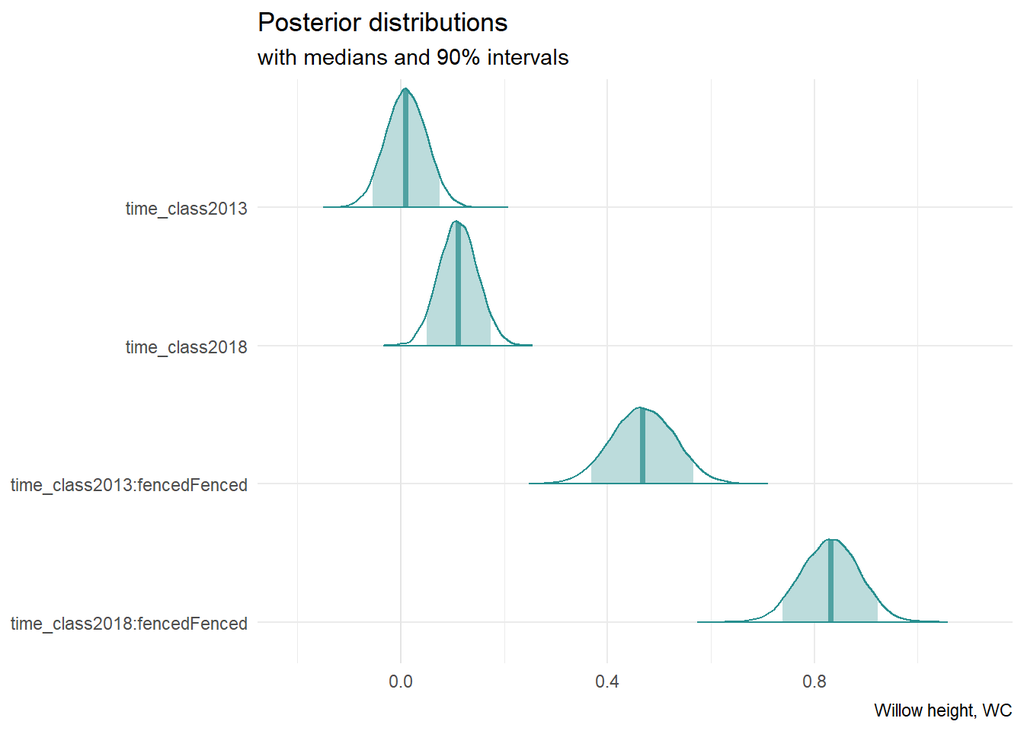

```r
bayesplot::mcmc_areas(posteriors.wc.ht,
           pars = c("time_class2013", "time_class2018", "time_class2013:fencedFenced","time_class2018:fencedFenced"),
           prob = 0.9) +
  theme_minimal() +
  labs(title = "Posterior distributions", subtitle = "with medians and 90% intervals", caption = "Willow height, WC")
```

```r
ggsave("./output/figures_202107/willow_height/mcmcarea_willowht_TCxF_wc.png", dpi = 300, width = 6.75, height = 3.75)
ggsave("./output/figures_202107/willow_height/mcmcarea_willowht_TCxF_wc.pdf", width = 6.75, height = 3.75)
```